# Lab 2

Tessa Mendoza

9/10/2020

##Searching for the Best Chocolates

1. How are the ratings distributed? Create both a histogram and a boxplot and describe them. Don’t forget to mention outliers, if there are any.

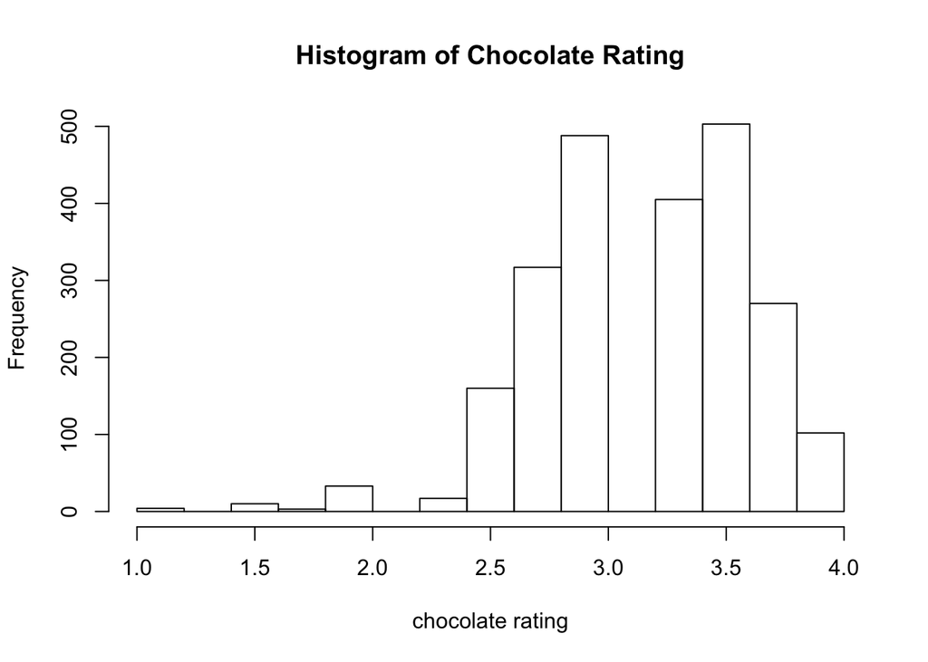

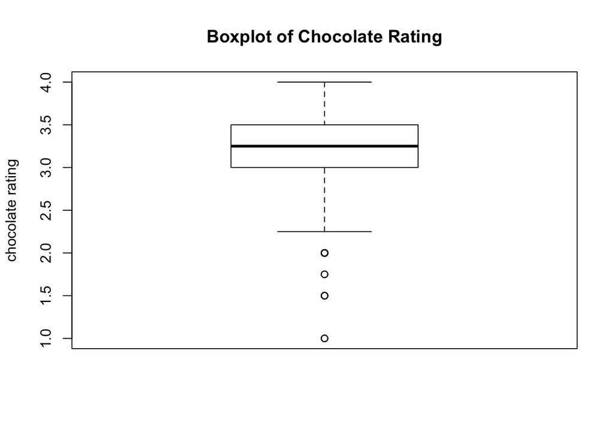

As shown in the plots above, the histogram of frequency of chocolate rating between 1 and 5 is skewed left. That is, there is a much larger representation of ratings between 2.5 and 4.0. Interestingly, there is not a given rating above 4.0, and only a couple below 2.5. However, being that these ‘outlying’ points fall within the rating range and include several of the same rating, they were kept in the data and will be considered during analysis. As shown in the histogram, the median of the data is around 3.25.

2. How does the number of ratings depend on the year? Draw a bar chart of the number of reports.

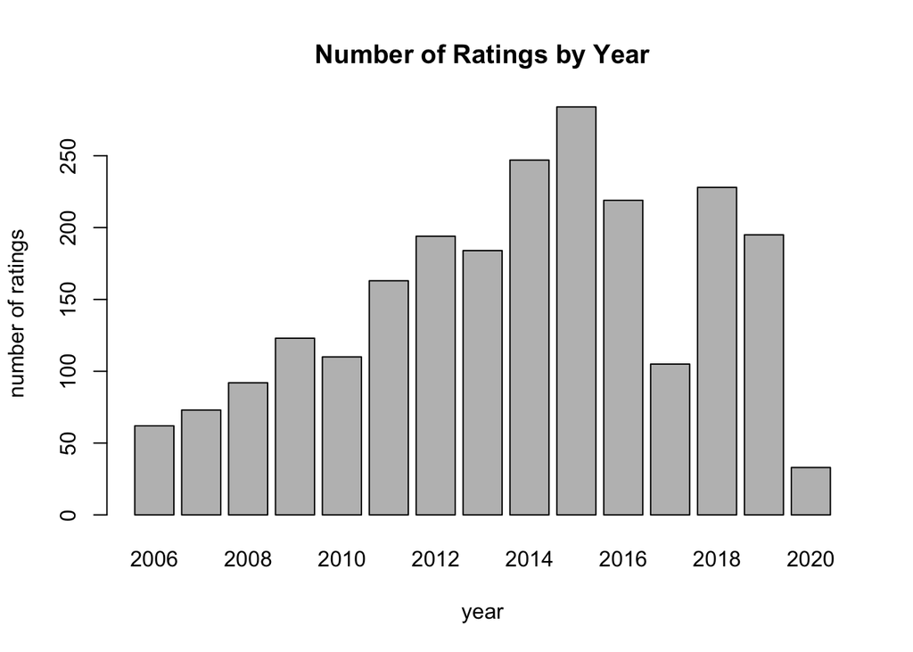

3. Do ratings depend on the cacao percentage of a chocolate bar? Create both numerical and graphical summaries, and explain.

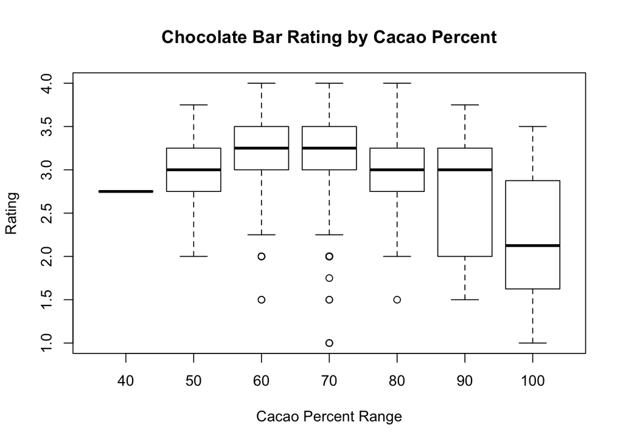

Yes, the rating of a chocolate bar is correlated to the cacao percentage of that bar. This is evident from the boxplot above, which shows how each 10% range of cacao percent (with a bar of 54%, for example, falling into the 50% range) varies its interquartile range and median value. As we see from this initial analysis, the IQR is much smaller for chocolate bars with 50-80% cacao, but the range increases for chocolate bars above 90% cacao. In addition, the median rating drops significantly for chocolate bars with 100% cacao. Thus, overall, the rating of chocolate with 100% cacao is lower than chocolate with lower percentage cacao. In fact, the table below provides a numerical summary of the mean rating score for each cacao percent range. The average rating for 60% chocolate bars, 3.21, is much higher than the 100% bars at 2.25.

```r
M <- tapply(choco$Rating, INDEX = choco$PercentRange, FUN = mean)
M
```

```
##       40       50       60       70       80       90      100
## 2.750000 2.956897 3.211940 3.211089 3.038690 2.730769 2.250000
```

```r
commonwords <- sort(table(choco$Characteristics1))
creamy <- choco[choco$Characteristics1 == 'creamy', ]
sandy <- choco[choco$Characteristics1 == 'sandy', ]
gritty <- choco[choco$Characteristics1 == 'gritty', ]
nutty <- choco[choco$Characteristics1 == 'nutty', ]
tart <- choco[choco$Characteristics1 == 'tart', ]
char_means <- data.frame(mean(creamy$Rating), mean(sandy$Rating), mean(gritty$Rating), mean(nutty$Rating), mean(tart$Rating))
print(char_means)
```

```
##   mean.creamy.Rating. mean.sandy.Rating. mean.gritty.Rating. mean.nutty.Rating.
## 1            3.484568           3.091418            2.909091           3.246795
##   mean.tart.Rating.
## 1          3.516667
```

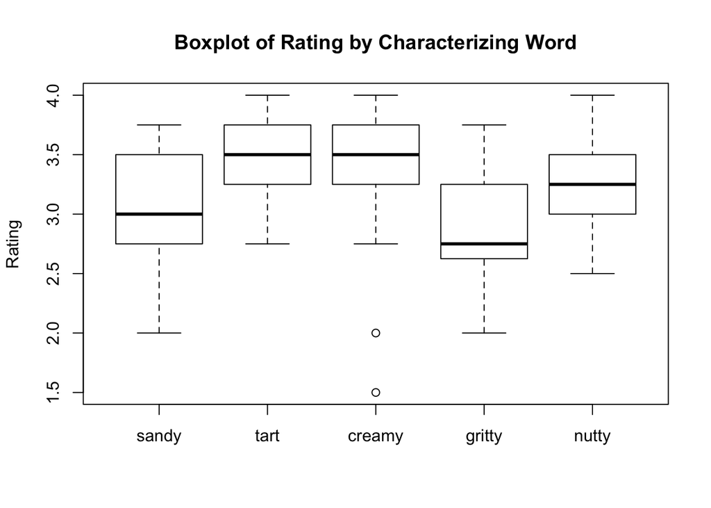

5. As a group, we discussed analyzing how the percentage of cacao in a chocolate bar and the origin location of the chocolate may affect how it is rated, and thus, it’s overall taste. To do this, we will determine the mean and median data for chocolate at each percentage, or in a range of percentages, and graph it against each other. For the location, we consider grouping by region and determining mean rating.